# Introduction

There are 4 cells that ask for changes below, the rest should run as long as you use the variable names I ask for in the questions.

```python
import rasterio
import a301
import numpy as np
from matplotlib import pyplot as plt
from matplotlib.colors import Normalize
from a301.landsat.landsat_metadata import landsat_metadata
import cartopy
from rasterio.windows import Window
from pyproj import transform as proj_transform
from pyproj import Proj
from a301.landsat.toa_reflectance import calc_reflc_8
import pprint
from a301.utils.data_read import download
from pathlib import Path
from affine import Affine
from IPython.display import Image
from a301.landsat.toa_reflectance import calc_refl_457, calc_reflc_8
from mpl_toolkits.axes_grid1 import make_axes_locatable
```

# Get bands 3, 4, 5 fullsize (green, red, near-ir)

At the end of this cell you shiould have the following path objects for your spring scene:

meta_bigfile, band3_bigfile, band4_bigfile, band5_bigfile

that point to your landsat TIF and mtl.txt files.

```python
dest_folder=a301.data_dir / Path("landsat8_2015_05_29")
band3_bigfile=list(dest_folder.glob("*_B3.TIF"))[0]
band4_bigfile=list(dest_folder.glob("*_B4.TIF"))[0]
band5_bigfile=list(dest_folder.glob("*_B5.TIF"))[0]
meta_bigfile=list(dest_folder.glob("*MTL.txt"))[0]
```

# This cell reads in your affine transform, metadata and profile

Using band4_bigfile (arbitrary)

```python
metadata=landsat_metadata(meta_bigfile)
with rasterio.open(band4_bigfile) as raster:
    big_transform=raster.transform
    big_profile=raster.profile

zone = metadata.UTM_ZONE
crs = cartopy.crs.UTM(zone, southern_hemisphere=False)
p_utm=Proj(crs.proj4_init)
p_lonlat=Proj(proj='latlong',datum='WGS84')
```

```
Scene LC80470272015149LGN02 center time is 2015-05-29 19:00:54
```

# This cell gets the right reflection function for your satellite

```python
refl_dict={'LANDSAT_7':calc_refl_457,'LANDSAT_8':calc_reflc_8}
satellite=metadata.SPACECRAFT_ID
refl_fun=refl_dict[satellite]
```

# Define a subscene window and a transform

In the cell below, get the upper left col,row (ul_col,ul_row) and upper left and lower right x,y (ul_x,ul_y,lr_x,lr_y) coordinates the upper left corner of your subscene as in the image_zoom notebook. Use ul_col, ul_row, ul_x, ul_y plus your subscene width and height to make a rasterio window and new transform.

```
window=Window(ul_col, ul_row, small_width, small_height)
new_affine=Affine(30.,0.,ul_x,0.,-30.,ul_y)
extent = [ul_x,lr_x,lr_y,ul_y]
```

```python
onp_lon = -123.6044
onp_lat = 47.8021
onp_x, onp_y =proj_transform(p_lonlat,p_utm,onp_lon, onp_lat)
onp_col, onp_row = ~big_transform*(onp_x,onp_y)
onp_col, onp_row = int(onp_col), int(onp_row)
l_col_offset= -100
t_row_offset= -100
small_height= 200
small_width = 200
ul_col=onp_col + l_col_offset
ul_row=onp_row + t_row_offset
ul_ul_xy = big_transform*(ul_col,ul_row)
ul_lr_xy = big_transform*(ul_col+small_width,ul_row+small_height)

ul_x, ul_y = ul_ul_xy[0], ul_ul_xy[1]
lr_x, lr_y = ul_lr_xy[0], ul_lr_xy[1]
new_affine=(30.,0.,ul_x,0.,-30.,ul_y)
small_window=Window(ul_col, ul_row, small_width, small_height)
extent = [ul_x,lr_x,lr_y,ul_y]
```

# Read only the window pixels from the band 3, 4, 5 files

```python
refl_dict=dict()
for bandnum,filepath in zip([3,4,5],[band3_bigfile,band4_bigfile,band5_bigfile]):
    with rasterio.open(filepath) as src:
        counts = src.read(1, window=small_window)
        refl_vals = refl_fun(counts,bandnum,metadata)
        refl_dict[bandnum]=refl_vals
```

# In the next cell calculate your ndvi

Save it in a variable called ndvi

```python
ndvi = (refl_dict[5] - refl_dict[4])/(refl_dict[5] + refl_dict[4])
```

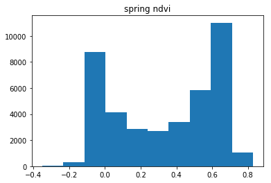

```python
plt.hist(ndvi[~np.isnan(ndvi)].flat);
plt.title('spring ndvi')
plt.savefig('spring_ndvi.png')
```

# In the next cell plot a mapped ndvi image with a red dot in your ul corner and a white dot in your lr corner

Adjust this plot to fit your image. Just delete the bottom line and work with the provided commands

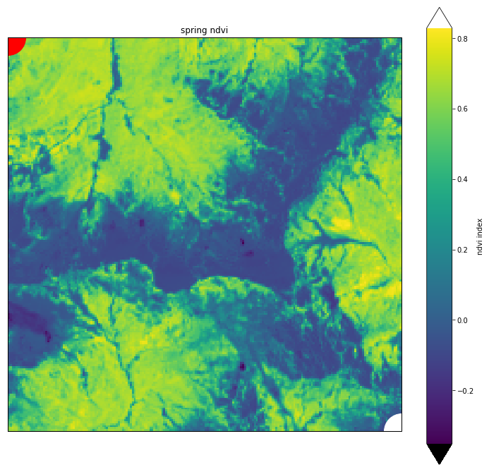

```python
vmin=0.0
vmax=0.8
the_norm=Normalize(vmin=vmin,vmax=vmax,clip=False)
palette='viridis'
pal = plt.get_cmap(palette)
pal.set_bad('0.75') #75% grey for out-of-map cells
pal.set_over('w')  #color cells > vmax red
pal.set_under('k')  #color cells < vmin black
fig, ax = plt.subplots(1, 1,figsize=[10,15],
                       subplot_kw={'projection': crs})
col=ax.imshow(ndvi,origin="upper",
         extent=extent,transform=crs)
ax.plot(ul_x,ul_y,'ro',markersize=50)
ax.plot(lr_x,lr_y,'wo',markersize=50)
ax.set(title="spring ndvi")
cbar_ax = fig.add_axes([0.95, 0.2, 0.05, 0.6])
cbar=ax.figure.colorbar(col,extend='both',cax=cbar_ax,orientation='vertical')
cbar.set_label('ndvi index')
```